# Model

Garrett Grolemund

Hadley Wickham

# Model

A model is a function that summarizes how the values of one variable vary in relation to the values of other variables. Models play a large role in hypothesis testing and prediction, but for the moment you should think of models just like you think of statistics. A statistic summarizes a *distribution* in a way that is easy to understand; and a model summarizes *covariation* in a way that is easy to understand. In other words, a model is just another way to describe data.

This chapter will explain how to build useful models with R.

### Outline

*Section 1* will show you how to build linear models, the most commonly used type of model. Along the way, you will learn R’s model syntax, a general syntax that you can reuse with most of R’s modeling functions.

*Section 2* will show you the best ways to use R’s model output, which often requires additional wrangling.

*Section 3* will teach you to build and interpret multivariate linear models, models that use more than one explanatory variable to explain the values of a response variable.

*Section 4* will explain how to use categorical variables in your models and how to interpret the results of models that use categorical variables. Here you will learn about interaction effects, as well as logistic models.

*Section 5* will present a logical way to extend linear models to describe non-linear relationships.

## Linear models

Have you heard that a relationship exists between your height and your income? It sounds far-fetched—and maybe it is—but many people believe that taller people will be promoted faster and valued more for their work, an effect that increases their income. Could this be true?

Luckily, it is easy to measure someone’s height, as well as their income, which means that we can collect data relevant to the question. In fact, the Bureau of Labor Statistics has been doing this in a controlled way for over 50 years. The BLS [National Longitudinal Surveys (NLS)](https://www.nlsinfo.org/) track the income, education, and life circumstances of a large cohort of Americans across several decades. In case you are wondering just how your tax dollars are being spent, the point of the NLS is not to study the relationship between height and income, that’s just a lucky accident.

I’ve narrowed the data down to 10 variables:

- `id` - A number to identify each subject
- `income` - The self-reported income of each subject
- `height` - The height of each subject in inches
- `weight` - The weight of each subject in pounds
- `sex` - The sex of each subject
- `race` - The race of each subject
- `education` - The number of years of education completed by each subject
- `asvab` - Each subject’s score on the Armed Services Vocational Aptitude Battery (ASVAB), an intelligence assessment, out of 100.
- `sat_math` - Each subject’s score on the math portion of the Scholastic Aptitude Test (SAT), out of 800.
- `bdate` - Month of birth with 1 = January.

```r
head(heights)
```

```
##   id income height weight    sex     race education  asvab sat_math bdate
## 1  1  70000     67    152 female    other        NA 45.070      550     9
## 2  2  83000     67    180   male hispanic        NA 58.483      550     7
## 3  4  29000     61    200 female hispanic        NA 37.012       NA     2
## 4  5  76000     66    190   male hispanic        NA     NA      350    10
## 5  6  15000     NA     NA female hispanic        NA 22.001      350     1
## 6  9  54000     71    200   male    other        NA     NA      550    10
```

Now that you have the data, you can visualize the relationship between height and income. But what does the data say? How would you describe the relationship?

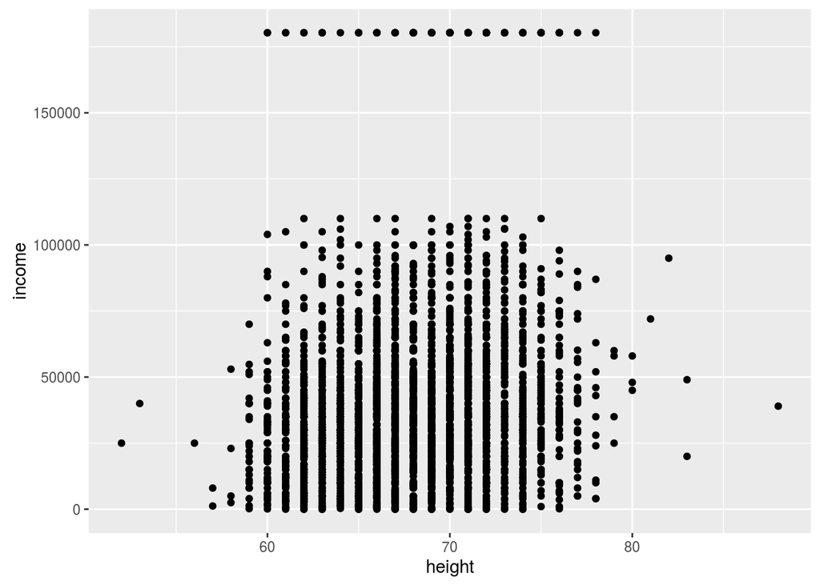

```r
ggplot(data = heights, mapping = aes(x = height, y = income)) +
  geom_point()
```

First, let’s address a distraction: the data is censored in an odd way. The y variable is income, which means that there are no y values less than zero. That’s not odd. However, there are also no y values above $180,331. In fact, there are a line of unusual values at exactly $180,331. This is because the Bureau of Labor Statistics removed the top 2% of income values and replaced them with the mean value of the top 2% of values, an action that was not designed to enhance the usefulness of the data for data science.

Also, you can see that heights have been rounded to the nearest inch.

Setting those concerns aside, we can measure the correlation between height and income with R’s `cor()` function. Correlation, $r$ from statistics, measures how strongly the values of two variables are related. The sign of the correlation describes whether the variables have a positive or negative relationship. The magnitude of the correlation describes how strongly the values of one variable determine the values of the second. A correlation of 1 or -1 implies that the value of one variable completely determines the value of the second variable.

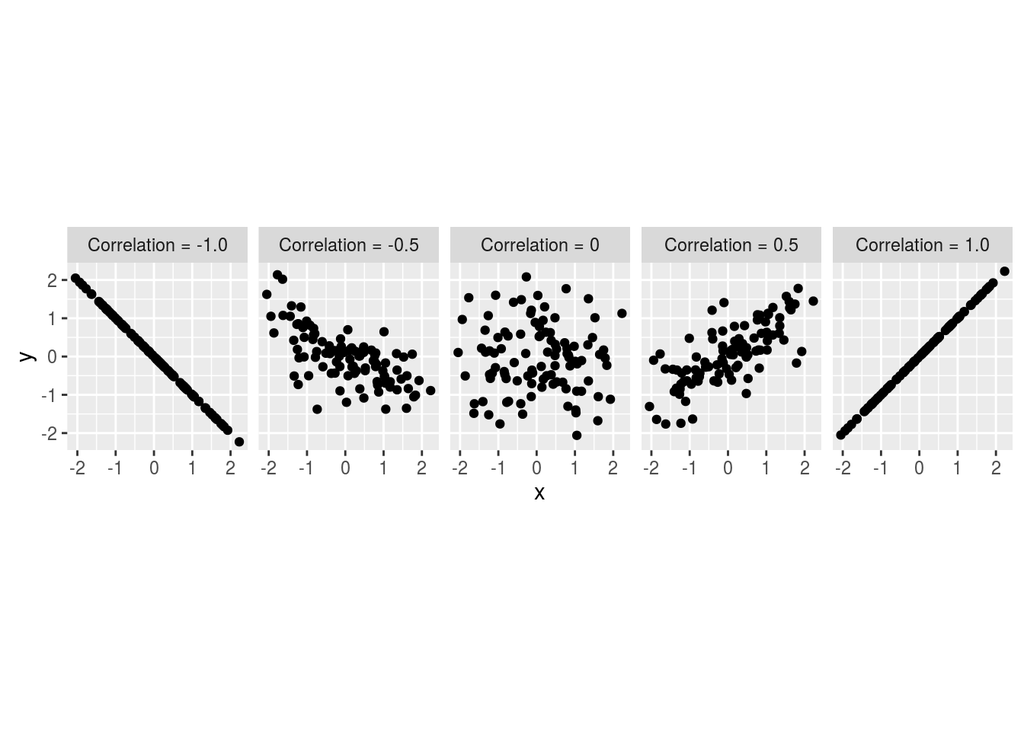

The correlation suggests that heights may have a small effect on income.

```r
cor(heights$height, heights$income, use = "na")
```

```
## [1] 0.1748599
```

A model describes the relationship between two or more variables. There are multiple ways to describe any relationship. Which is best?

A common choice: decide the form of the relationship, then minimize residuals.

Use R’s `lm()` function to fit a linear model to your data. The first argument of `lm()` should be a formula, two or more variables separated by a `~`. You’ve seen formulas before, we used them in Chapter 2 to facet graphs.

```r
income ~ height
```

```
## income ~ height
```

```r
h <- lm(income ~ height, data = heights)
h
```

```
##
## Call:
## lm(formula = income ~ height, data = heights)
##
## Coefficients:
## (Intercept)       height
##      -50084         1329
```

`lm()` fits a straight line that describes the relationship between the variables in your formula. You can picture the result visually like this.

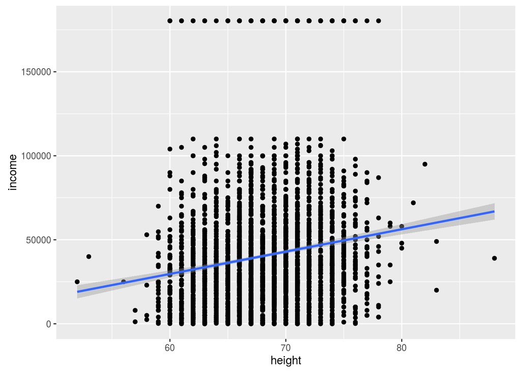

`lm()` treats the variable(s) on the right-hand side of the formula as *explanatory variables* that partially determine the value of the variable on the left-hand side of the formula, which is known as the *response variable*. In other words, it acts as if the *response variable* is determined by a function of the *explanatory variables*. It then spots the linear function that best fits the data.

Linear models are straightforward to interpret. Incomes have a baseline mean of $-5.008426\times 10^{4}$. Each one inch increase of height above zero is associated with an increase of $1329.0965489$ in income.

```r
summary(h)
```

```
##
## Call:
## lm(formula = income ~ height, data = heights)
##
## Residuals:
##    Min     1Q Median     3Q    Max
## -50777 -19623  -6294  11035 150669
##
## Coefficients:
##             Estimate Std. Error t value Pr(>|t|)
## (Intercept) -50084.3     8286.2  -6.044 1.65e-09 ***
## height        1329.1      121.7  10.920  < 2e-16 ***
## ---
## Signif. codes:  0 '***' 0.001 '**' 0.01 '*' 0.05 '.' 0.1 ' ' 1
##
## Residual standard error: 31320 on 3781 degrees of freedom
##   (205 observations deleted due to missingness)
## Multiple R-squared:  0.03058,    Adjusted R-squared:  0.03032
## F-statistic: 119.3 on 1 and 3781 DF,  p-value: < 2.2e-16
```

To create a model without an intercept, add 0 to the formula.

```r
lm(income ~ 0 + height, data = heights)
```

```
##
## Call:
## lm(formula = income ~ 0 + height, data = heights)
##
## Coefficients:
## height
##  594.8
```

## Using model output

R’s model output is not very tidy. It is designed to provide a data store from which you can extract information with helper functions. You will learn more about tidy data in Tidy Data.

```r
coef(h)
```

```
## (Intercept)      height
##  -50084.260    1329.097
```

```r
predict(h)[1:5]
```

```
##        1        2        3        4        6
## 38965.21 38965.21 30990.63 37636.11 44281.60
```

```r
resid(h)[1:5]
```

```
##         1         2         3         4         6
## 31034.791 44034.791 -1990.630 38363.887  9718.405
```

The `broom` package provides the most useful helper functions for working with R models. `broom` functions return the most useful model information as data frames, which lets you quickly embed the information into your data science workflow.

### tidy()

```r
tidy(h)
```

```
##          term   estimate std.error statistic      p.value
## 1 (Intercept) -50084.260 8286.2242  -6.04428 1.646132e-09
## 2      height   1329.097  121.7082  10.92035 2.350433e-27
```

### glance()

```r
glance(h)
```

```
##    r.squared adj.r.squared    sigma statistic      p.value df    logLik
## 1 0.03057598    0.03031958 31321.84  119.2541 2.350433e-27  2 -44528.73
##        AIC      BIC     deviance df.residual
## 1 89063.46 89082.17 3.709379e+12        3781
```

### augment()

```r
augment(h)[1:5, ]
```

```
##   .rownames income height  .fitted  .se.fit    .resid         .hat
## 1         1  70000     67 38965.21 522.3168 31034.791 0.0002780824
## 2         2  83000     67 38965.21 522.3168 44034.791 0.0002780824
## 3         3  29000     61 30990.63 987.7539 -1990.630 0.0009944958
## 4         4  76000     66 37636.11 562.0417 38363.887 0.0003219901
## 5         6  54000     71 44281.60 629.8957  9718.405 0.0004044294
##     .sigma      .cooksd  .std.resid
## 1 31321.92 1.365803e-04  0.99097327
## 2 31317.79 2.749681e-04  1.40607684
## 3 31325.97 2.012443e-06 -0.06358568
## 4 31319.77 2.416812e-04  1.22502587
## 5 31325.58 1.948316e-05  0.31033841
```

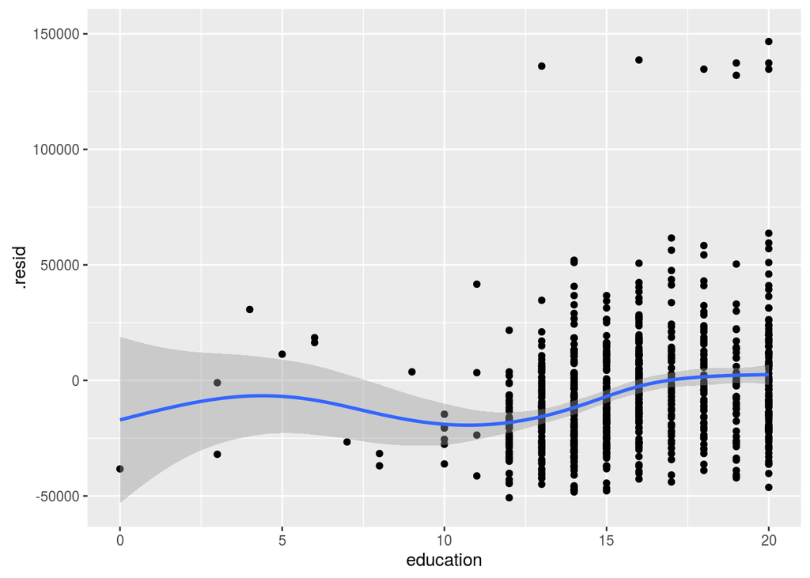

```r
heights2 <- augment(h, heights)
ggplot(data = heights2, mapping = aes(x = education, y = .resid)) +
  geom_point() +
  geom_smooth()
```

## Multivariate models

There appears to be a relationship between a person’s education and how poorly the model predicts their income. When we graphed the model residuals against `education` above, we see that the more a person is educated, the worse the model underestimates their income.

Patterns in the residuals suggest that relationships exist between y and other variables, even when the effect of heights is accounted for.

Add variables to a model by adding variables to the right-hand side of the model formula.

```r
income ~ height + education
```

```
## income ~ height + education
```

```r
he <- lm(income ~ height + education, data = heights)
tidy(he)
```

```
##          term    estimate  std.error statistic      p.value
## 1 (Intercept) -49555.7196 15736.4736 -3.149099 1.701564e-03
## 2      height    713.6964   219.6917  3.248627 1.210401e-03
## 3   education   2232.3163   315.2574  7.080932 3.253889e-12
```

### Interpretation

The coefficient of each variable represents the increase in income associated with a one unit increase in the variable *when all other variables are held constant*.

### Interaction effects

```r
tidy(lm(income ~ height + education, data = heights))
```

```
##          term    estimate  std.error statistic      p.value
## 1 (Intercept) -49555.7196 15736.4736 -3.149099 1.701564e-03
## 2      height    713.6964   219.6917  3.248627 1.210401e-03
## 3   education   2232.3163   315.2574  7.080932 3.253889e-12
```

```r
tidy(lm(income ~ height + education + height:education, data = heights))
```

```
##               term     estimate   std.error  statistic   p.value
## 1      (Intercept) -24750.01262 87119.26532 -0.2840934 0.7764159
## 2           height    343.30627  1298.15800  0.2644565 0.7914997
## 3        education    642.55520  5500.44525  0.1168188 0.9070345
## 4 height:education     23.74363    82.01584  0.2895005 0.7722771
```

```r
tidy(lm(income ~ height * education, data = heights))
```

```
##               term     estimate   std.error  statistic   p.value
## 1      (Intercept) -24750.01262 87119.26532 -0.2840934 0.7764159
## 2           height    343.30627  1298.15800  0.2644565 0.7914997
## 3        education    642.55520  5500.44525  0.1168188 0.9070345
## 4 height:education     23.74363    82.01584  0.2895005 0.7722771
```

## Categorical variables

What about sex? Many sources have observed that there is a difference in income between genders. Might this explain the height effect? We can find the effect of height independent of sex by adding sex to the model; however, sex is a categorical variable.

### Factors

R stores categorical data as factors. If you add a string to a model, R will convert it to a factor for the purposes of the model.

A factor is an integer vector with a levels attribute. You can make a factor with `factor()`.

```r
fac <- factor(c("c", "a", "b"),
  levels = c("a", "b", "c"),
  labels = c("blond", "brunette", "red"))
fac
```

```
## [1] red      blond    brunette
## Levels: blond brunette red
```

```r
unclass(fac)
```

```
## [1] 3 1 2
## attr(,"levels")
## [1] "blond"    "brunette" "red"
```

Each level of the factor (i.e. unique value) is encoded as an integer and displayed with the label that is associated with that integer.

If you use factors outside of a model, you will notice some limiting behavior:

- You cannot add values to a factor that do not appear in its levels.
- Factors retain all of their levels when you subset them. To avoid this use `drop = TRUE`.

  ```r
  fac[1]
  ```

  ```
  ## [1] red
  ## Levels: blond brunette red
  ```

  ```r
  fac[1, drop = TRUE]
  ```

  ```
  ## [1] red
  ## Levels: red
  ```

- If you coerce a factor to a number with `as.numeric()`, R will convert the integer vector that underlies the factor to a number, not the level labels that you see when you print the factor.

  ```r
  num_fac <- factor(1:3, levels = 1:3, labels = c("100", "200", "300"))
  num_fac
  ```

  ```
  ## [1] 100 200 300
  ## Levels: 100 200 300
  ```

  ```r
  as.numeric(num_fac)
  ```

  ```
  ## [1] 1 2 3
  ```

  To coerce the labels that you see to a new data type, first coerce the factor to a character string with `as.character()`

```r
as.numeric(as.character(num_fac))
```

```
## [1] 100 200 300
```

### Interpretation

Add categorical variables to a model in the same way that you would add continuous variables.

```r
s <- lm(income ~ sex, data = heights)
tidy(s)
```

```
##          term  estimate std.error statistic      p.value
## 1 (Intercept)  45236.74  677.3342  66.78644 0.000000e+00
## 2   sexfemale -11055.99  991.2673 -11.15339 1.811266e-28
```

Every level of the factor except one receives its own coefficient. The missing level acts as a baseline.

To change the baseline, create a new factor with a new levels attribute. R will use the first level in the levels attribute as the baseline.

```r
heights$sex <- factor(heights$sex, levels = c("male", "female"))
heights %>%
  group_by(sex)  %>%
  do(glance(lm(income ~ height, data = .)))
```

```
## Source: local data frame [2 x 12]
## Groups: sex [2]
##
##      sex   r.squared adj.r.squared    sigma statistic      p.value    df
##   <fctr>       <dbl>         <dbl>    <dbl>     <dbl>        <dbl> <int>
## 1   male 0.006125574   0.005632825 35234.16 12.431433 0.0004315908     2
## 2 female 0.002313385   0.001747161 25873.00  4.085636 0.0434000987     2
## Variables not shown: logLik <dbl>, AIC <dbl>, BIC <dbl>, deviance <dbl>,
##   df.residual <int>.
```

### Logistic models

So far the y variable of our models has been a continuous variable, `income`. You can use linear regression to model a categorical y variable by transforming y into a continuous variable with a *link function*. Then model fit a model to the results of the link function and use the link function to back transform and interpret the results.

The most common link function is the logit function, which transforms a bivariate y variable into a continuous range.

Use `glm()` to perform logistic regression in R.

```r
she <- glm(sex ~ height + education, family = binomial(link = "logit"), data = heights)
tidy(she)
```

```
##          term    estimate  std.error  statistic      p.value
## 1 (Intercept) 53.34168480 3.90364446  13.664586 1.652412e-42
## 2      height -0.80635302 0.05813811 -13.869611 9.680071e-44
## 3   education  0.08661413 0.04050411   2.138403 3.248402e-02
```

## Non-linear models

But what if the relationship between variables is not linear? For example, the relationship between income and education does not seem to be linear.

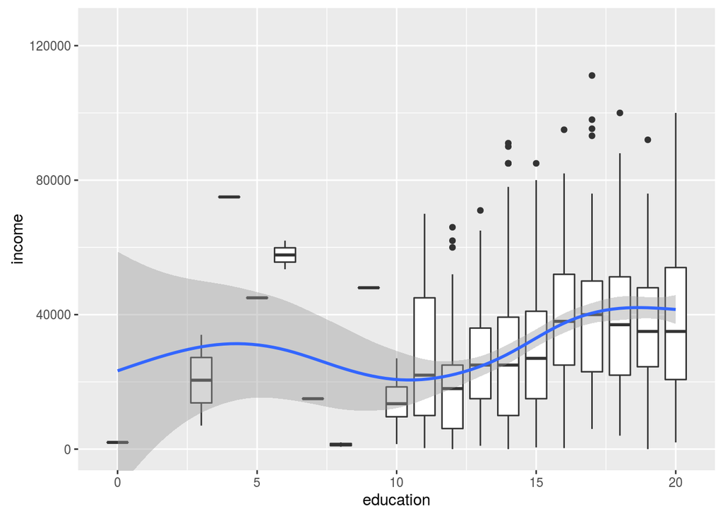

```r
ggplot(data = heights, mapping = aes(x = education, y = income)) +
  geom_boxplot(aes(group = education)) +
  geom_smooth() +
  coord_cartesian(ylim = c(0, 125000))
```

You can still use linear regression to model non-linear relationships.